# BF Group Project

## Decomposition using STL

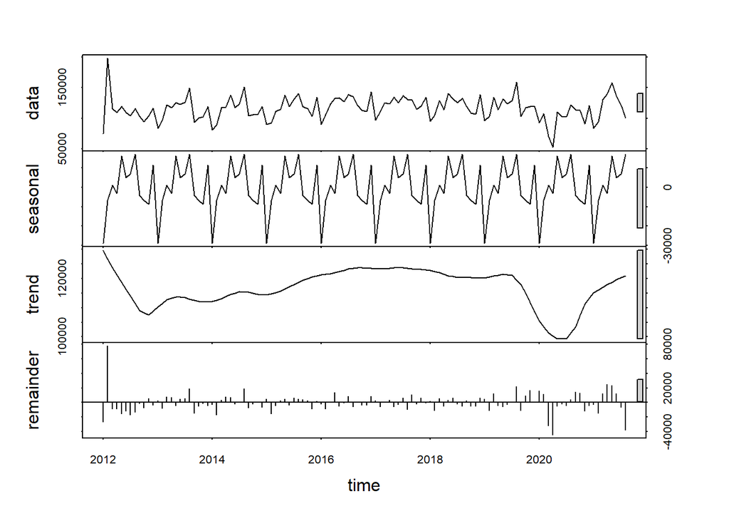

```r
honda_fit1 <- stl(honda_subts,s.window = "periodic")
plot(honda_fit1)
```

## Decomposition using Decompose

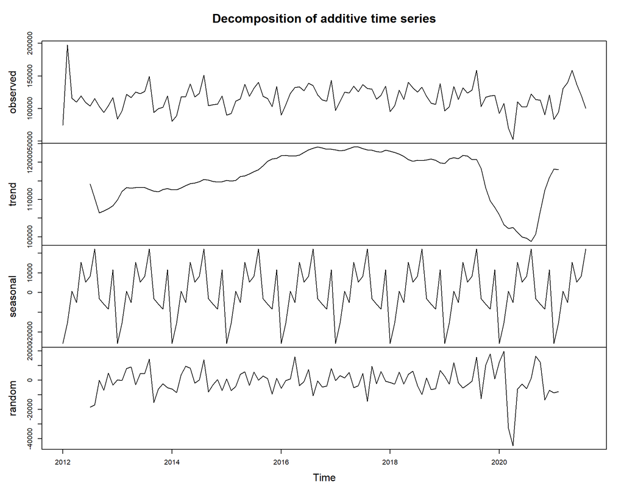

```r
honda_d_fit1 <- decompose(honda_subts)
plot(honda_d_fit1)
```

On a net basis, the trend line appears slightly upward trending to static.Seasonality continues to remain a major factor in the underlying data.

## Seasonally Adjust the Time-series:

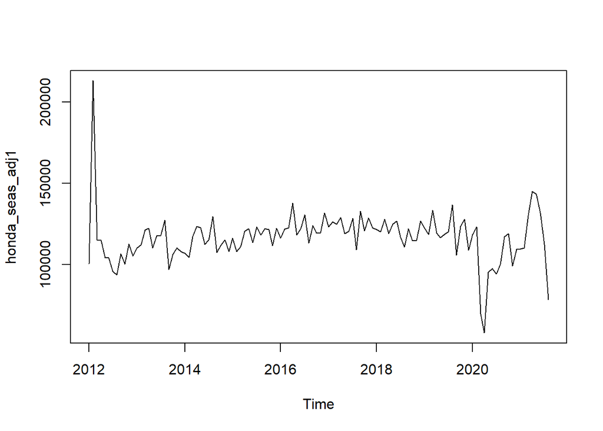

```r
honda_seas_adj1 <- seasadj(honda_d_fit1)
plot(honda_seas_adj1)
```

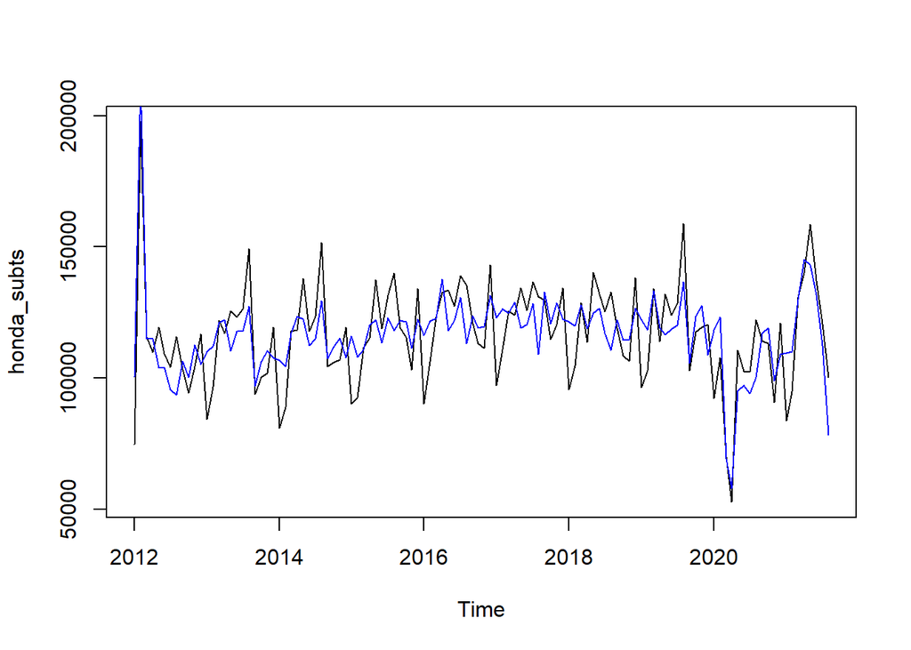

```r
plot(honda_subts)
lines(honda_seas_adj1,col="Blue")
```

#### Seasonal Indices:

```r
honda_d_fit1$type
```

```
## [1] "additive"
```

```r
honda_d_fit1$figure
```

```
##  [1] -25916.8295 -15442.0054    710.1797  -5088.9505  15405.9870   5408.2579
##  [7]   8368.5871  22099.0038  -2998.7879  -5914.9545  -8271.9777  11641.4899
```

```r
honda_s_indice1 <- round(honda_d_fit1$figure/10000,2)
honda_s_indice1
```

```
##  [1] -2.59 -1.54  0.07 -0.51  1.54  0.54  0.84  2.21 -0.30 -0.59 -0.83  1.16
```

Highest: August Lowest: January

After subsetting the data, the highest and lowest sales months are still the same indicating that the seasonality and trend is constant every year.

### Acf

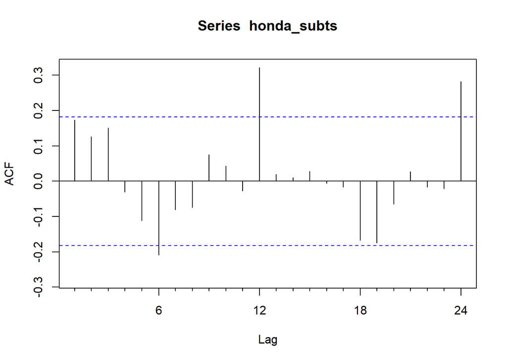

```r
honda_acf1 <- Acf(honda_subts,type="correlation")
```

Like the whole dataset, the subsetted dataset also has a correlation for every 12th lag due to the seasonality factor of the data.

## Mean Forecast

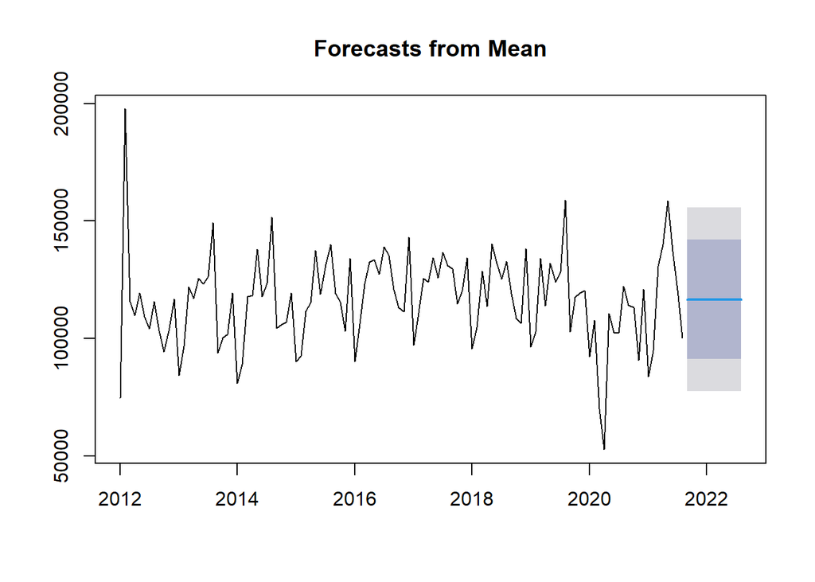

```r
honda_mean_f1 <- meanf(honda_subts,h=12)
plot(honda_mean_f1)
```

#### Accuracy for the Mean Forecast:

```r
acc_mean1 <- accuracy(honda_mean_f1)
acc_mean1
```

```
##                         ME     RMSE      MAE       MPE     MAPE     MASE
## Training set -4.514779e-12 19540.75 14673.75 -3.156998 13.60041 1.189225
##                   ACF1
## Training set 0.1739418
```

The MAPE value for Mean forecast is 13.6 percent which is better than the mean forecast value for the whole dataset.

## Naive Forecast

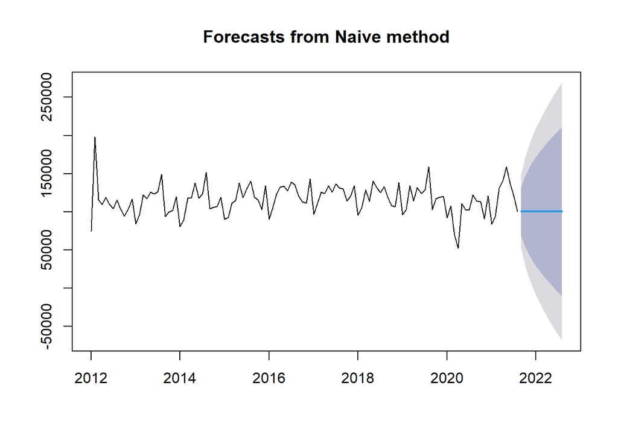

```r
honda_naive_fs <- naive(honda_subts,h=12)
plot(honda_naive_fs)
```

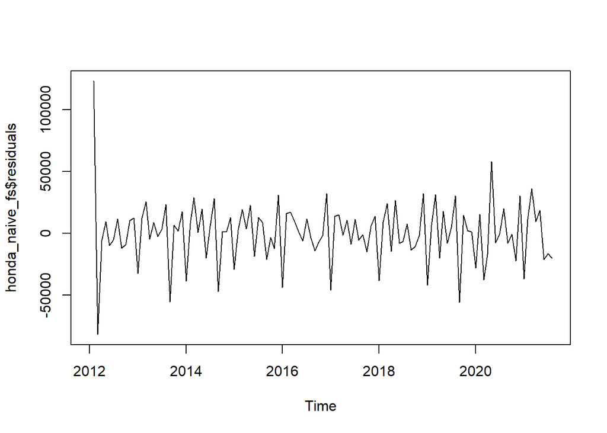

```r
plot(honda_naive_fs$residuals)
```

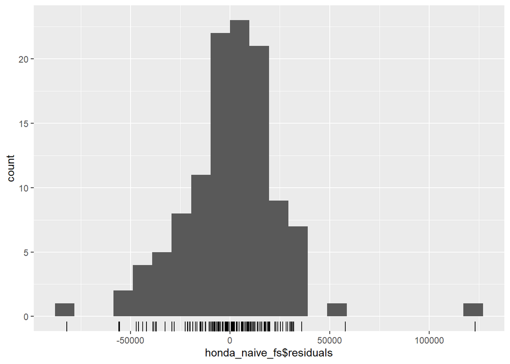

```r
gghistogram(honda_naive_fs$residuals)
```

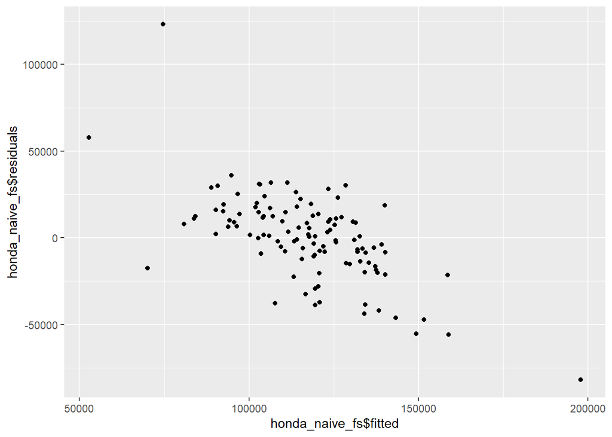

```r
ggplot(honda_subts,aes(x=honda_naive_fs$fitted,y=honda_naive_fs$residuals))+geom_point()
```

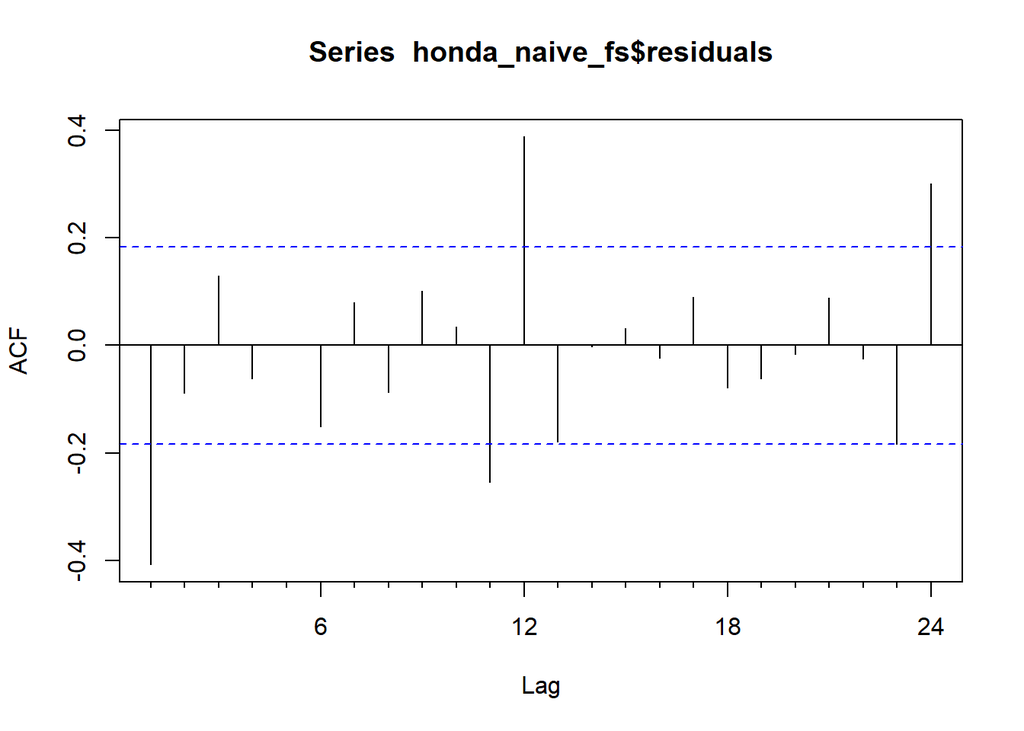

```r
Acf(honda_naive_fs$residuals)
```

```r
acc_naive1 <- accuracy(honda_naive_fs)
acc_naive1
```

```
##                    ME  RMSE      MAE       MPE     MAPE    MASE      ACF1
## Training set 223.7913 24873 17722.52 -2.023625 15.70898 1.43631 -0.407157
```

The subsetted naive forecast has histogram plot like the whole naive forecast, however, the accuracy measure is relatively better in the subset model at 15.7 percent vs. 16 percent for the whole model.

## Random Walk

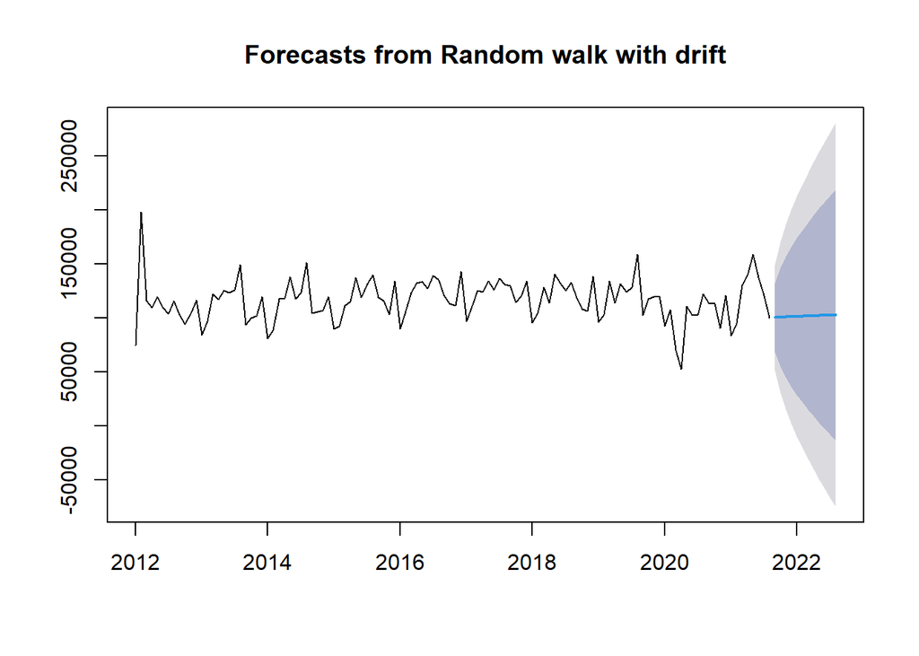

```r
honda_rwf_fs <- rwf(honda_subts,12,drift=TRUE)
plot(honda_rwf_fs)
```

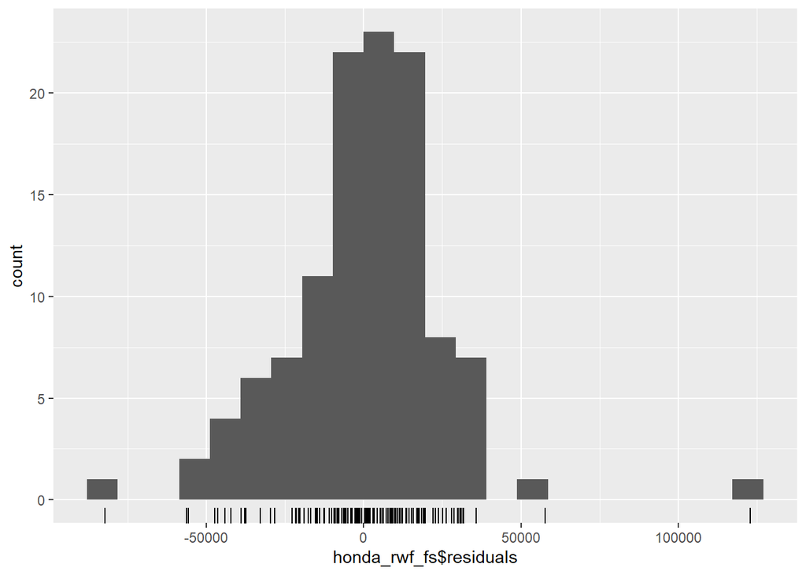

```r
gghistogram(honda_rwf_fs$residuals)
```

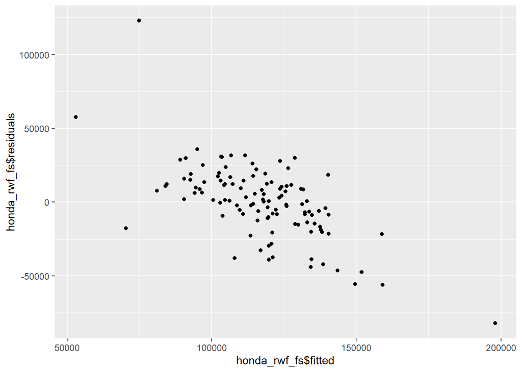

```r
ggplot(honda_subts,aes(x=honda_rwf_fs$fitted,y=honda_rwf_fs$residuals))+geom_point()
```

```r
acc_rwf1 <- accuracy(honda_rwf_fs)
acc_rwf1
```

```
##                        ME     RMSE      MAE       MPE     MAPE     MASE
## Training set 1.113572e-11 24871.99 17705.01 -2.220637 15.70804 1.434891
##                   ACF1
## Training set -0.407157
```

For the random walk model, the MAPE value is better than the whole dataset MAPE value and same as the subset Naive forecast of 15.7 percent.

## Snaive Forecast

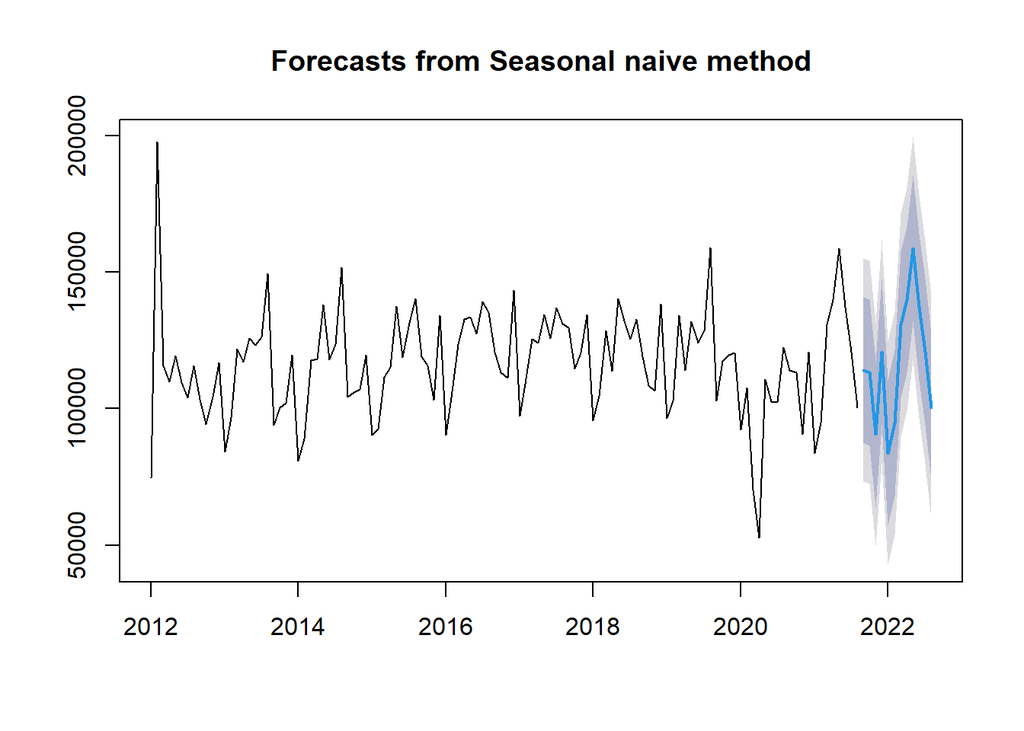

```r
honda_snaive_fs <- snaive(honda_subts,12)
plot(honda_snaive_fs)
```

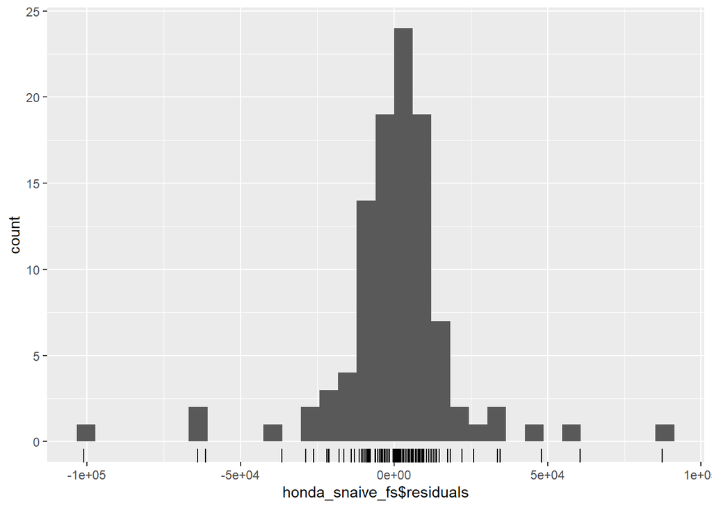

```r
gghistogram(honda_snaive_fs$residuals)
```

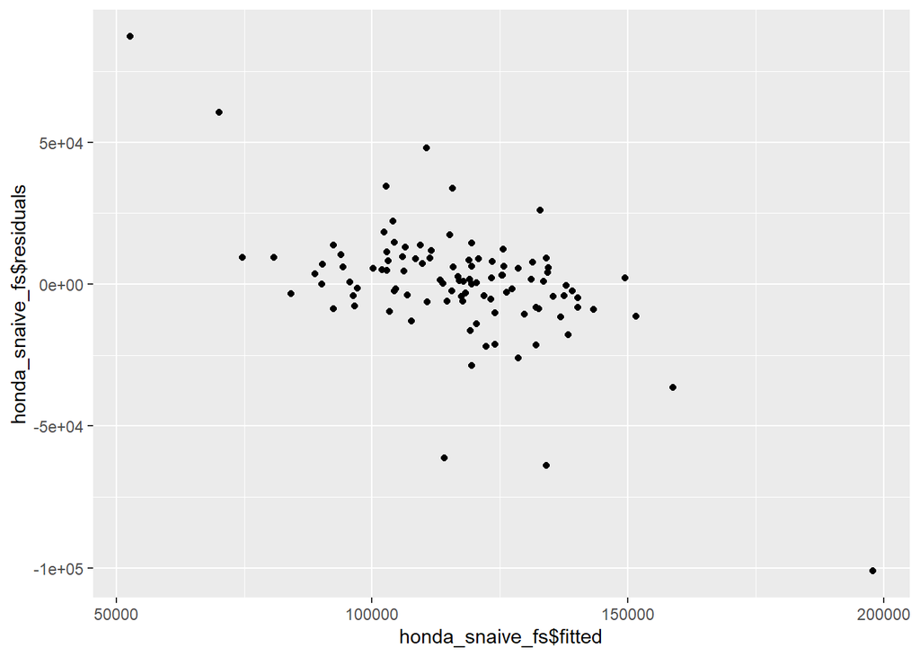

```r
ggplot(honda_subts,aes(x=honda_snaive_fs$fitted,y=honda_snaive_fs$residuals))+geom_point()
```

```r
acc_snaive1 <- accuracy(honda_snaive_fs)
acc_snaive1
```

```
##                    ME     RMSE      MAE       MPE     MAPE MASE    ACF1
## Training set 379.6154 20843.79 12338.92 -1.546314 11.46245    1 0.35779
```

In case of the subset Snaive forecast, the forecasts seems better than the forecast for the whole dataset. Also, the MAPE measure is better for the subset data with 11.46 percent.

## Simple Moving Average:

```r
honda_sma_f3s  <- ma(honda_subts,order = 3)
honda_sma_f6s <- ma(honda_subts,order = 6)
honda_sma_f12s <- ma(honda_subts,order = 12)
```

Plotting the time-line:

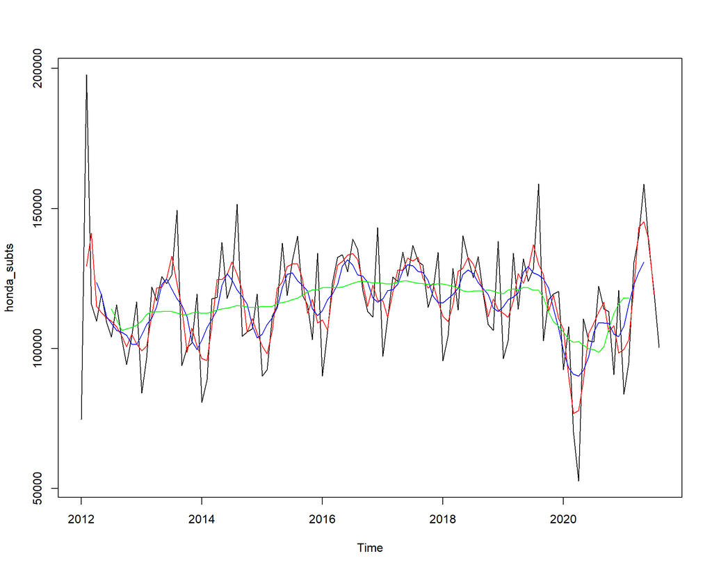

```r
plot(honda_subts)
lines(honda_sma_f3s,col="red")
lines(honda_sma_f6s,col="blue")
lines(honda_sma_f12s,col="green")
```

```r
honda_sma_forecast1s <- forecast(honda_sma_f12s,h=12)
honda_sma_forecast2s <- forecast(honda_sma_f3s,h=12)
honda_sma_forecast3s <- forecast(honda_sma_f6s,h=12)
```

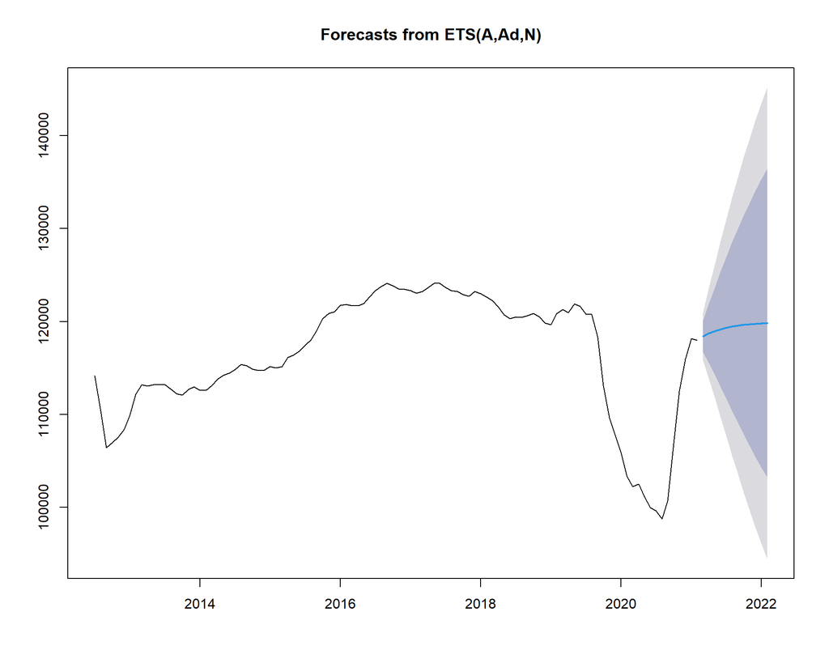

```r
plot(honda_sma_forecast1s)
```

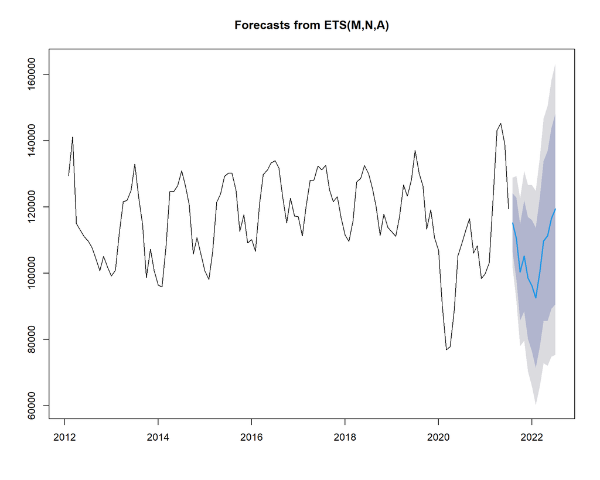

```r
plot(honda_sma_forecast2s)
```

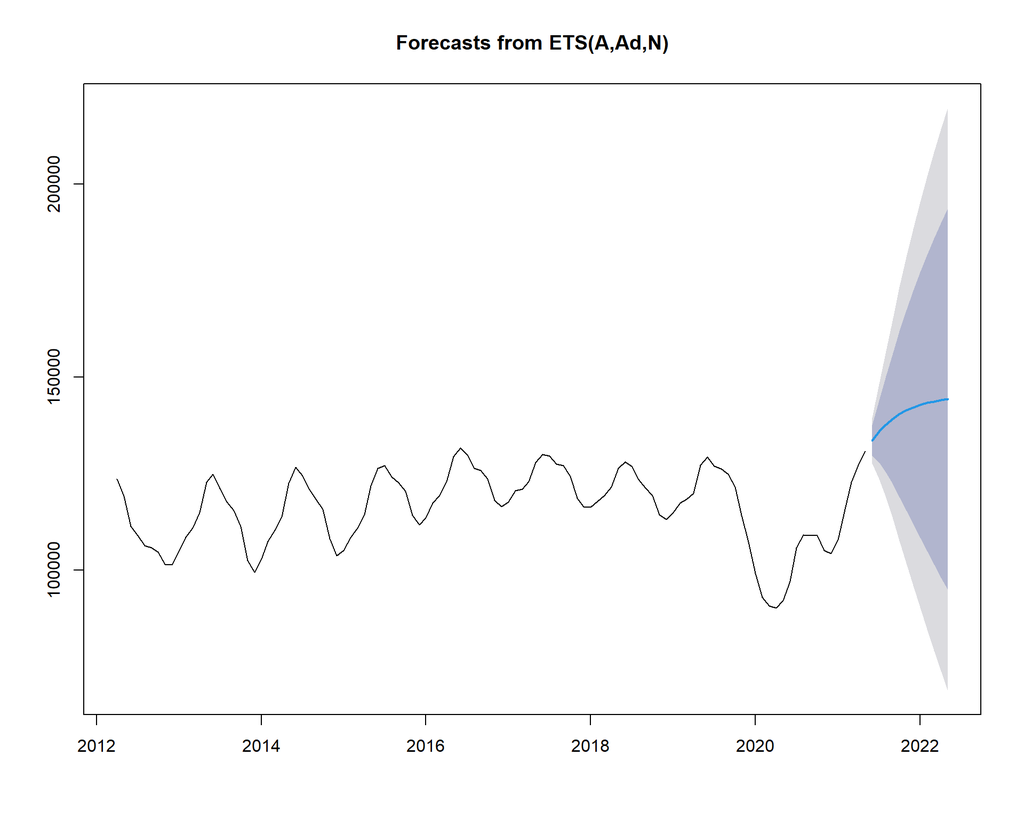

```r
plot(honda_sma_forecast3s)
```

In case of the simple moving averages for the subset of data, we can see that the green line represents the moving average with degree 12, which replicates the trend line of the subset of data. If one observes the forecast generated by the 12-period moving average model, the forecasts shows an upward trend over the next 12 months. In our view, this expectation is unrealistic, considering the persistent supply chain constraints that will negatively impact car sales. Therefore, in this context, we do not believe the 12-period moving average model is appropriate.

If we observe the moving average forecasts for degree 3 and 6, we can see that even for degree 6, the moving average forecast shows an upward trend instead of a downward trend hence this would also not be an ideal model to be considered. Such an expectation is far too optimistic, in our view.

The subsetted 3-period moving average model offers the most realistic outlook with volumes decreasing heading into the seasonally slower period (i.e., January) before seeing a seasonal recovery. Furthermore, as observed, the recovery is conservative, which we believe is appropriate in this unusual macroeconomic environment.

#### Accuracy for Simple moving average:

```r
acc_sma1s <- accuracy(honda_sma_forecast1s)
acc_sma2s <- accuracy(honda_sma_forecast2s)
acc_sma3s <- accuracy(honda_sma_forecast3s)
acc_sma2s
```

```
##                     ME     RMSE      MAE        MPE    MAPE      MASE      ACF1
## Training set -83.44906 6570.076 3944.066 -0.1992666 3.51278 0.4438829 0.2322076
```

```r
acc_sma3s
```

```
##                    ME     RMSE      MAE        MPE    MAPE      MASE      ACF1
## Training set 48.56033 2959.454 2498.026 0.09057913 2.16732 0.3731277 0.1577111
```

As we can see the moving average for degree 6 MAPE is 2.16 percent which is quite low. However, the forecast prediction seems to be off from the observed data. Hence considering this forecast would not be suitable as an accurate model prediction.

In case of moving average of degree 3, the MAPE is 3.5 percent which is also low. The forecasts also exhibits a reasonable outlook. This model could be considered as one of the ideal prediction models in our case.

## ETS method

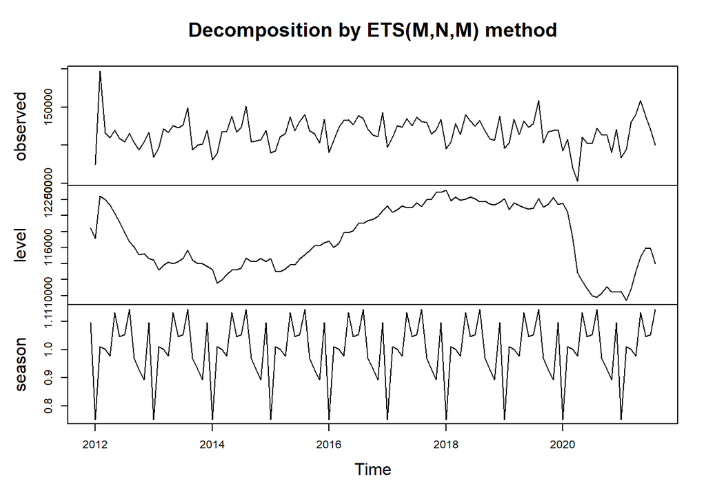

```r
honda_ets1 <- ets(honda_subts)
plot(honda_ets1)
```

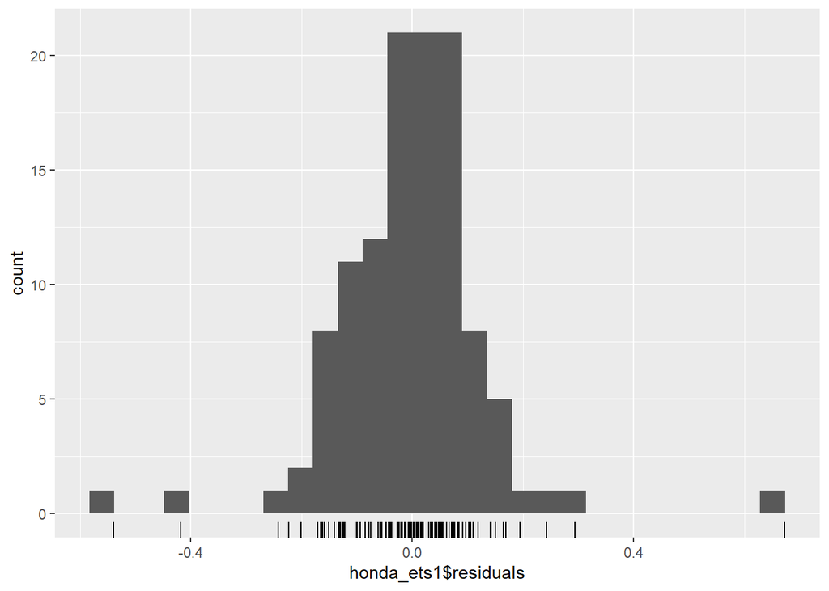

```r
gghistogram(honda_ets1$residuals)
```

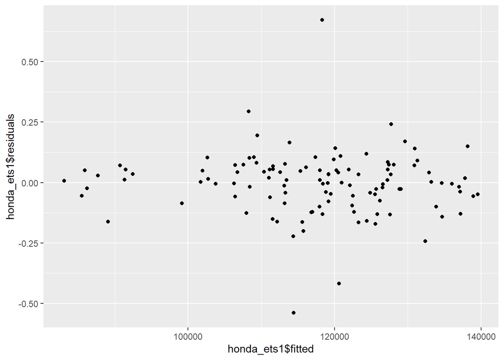

```r
ggplot(honda_subts,aes(x=honda_ets1$fitted,y=honda_ets1$residuals))+geom_point()
```

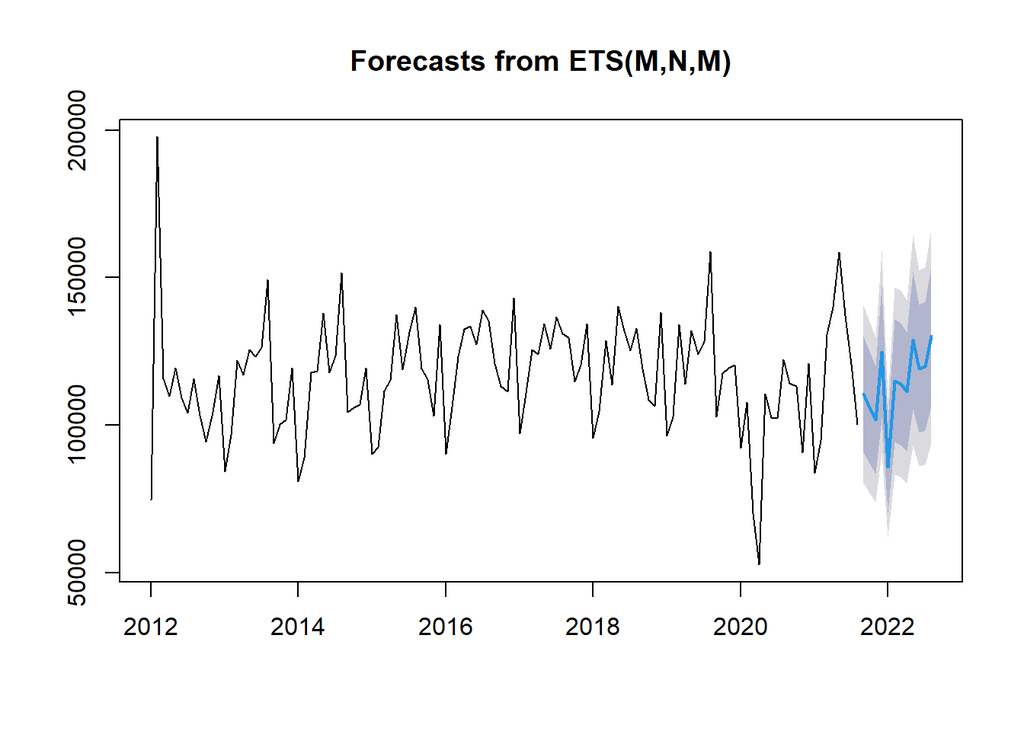

```r
honda_ets_forecast_s <- forecast(honda_ets1,h=12)
plot(honda_ets_forecast_s)
```

```r
acc_ets_s <- accuracy(honda_ets1)
acc_ets_s
```

```
##                     ME     RMSE      MAE       MPE     MAPE      MASE      ACF1
## Training set -603.0207 15479.48 10378.14 -2.424413 9.578832 0.8410892 0.2155979
```

In case of ETS model, the forecast looks similar to that of the ets prediction for the whole data. The MAPE measure is also about the same as that of the whole data at 9.57 percent. This is better than the Naive model but moving averages model seems much better in terms of forecasts as well as Accuracy measures than the ETS model.

## Holts-Winter

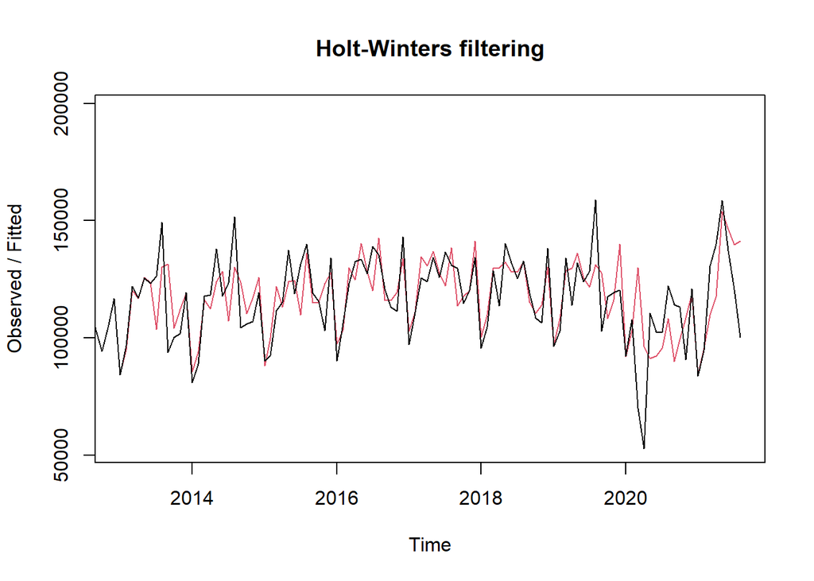

```r
honda_hw_fs <- HoltWinters(honda_subts)
plot(honda_hw_fs)
```

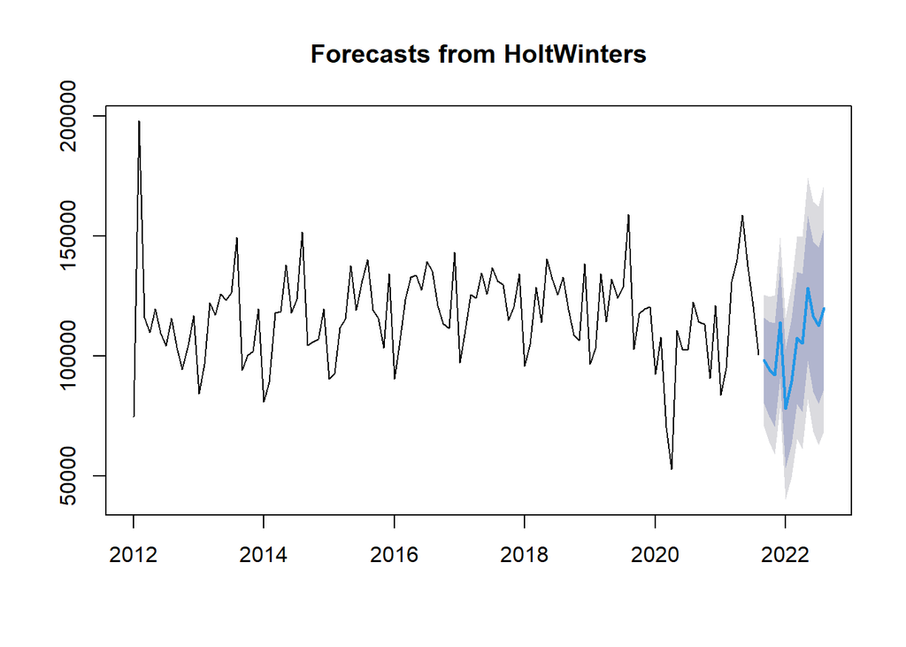

```r
honda_hw_forecast_s <- forecast(honda_hw_fs,h=12)
plot(honda_hw_forecast_s)
```

```r
acc_hws <- accuracy(honda_hw_forecast_s)
acc_hws
```

```
##                     ME     RMSE      MAE       MPE     MAPE      MASE
## Training set -881.4048 13920.11 9579.355 -2.189878 8.929293 0.7763526
##                    ACF1
## Training set 0.08416367
```

The Holtwinter for subset data is better than the Holtwinters for the whole data. The MAPE measure is proof itself that subset model is better than the whole data model with MAPE measure of 8.9 compared to MAPE measure of 9.87 for the whole data model.

# Comparing all accuracy Measures from a Table:

```r
row1 <- as.data.frame.array(acc_mean)
row1 <- rbind(acc_mean,acc_mean1,acc_naive,acc_naive1,acc_rwf,acc_rwf1,acc_snaive,acc_snaive1,acc_ets,acc_ets_s,acc_hw,acc_hws,
              acc_sma2,acc_sma2s,acc_sma3,acc_sma3s)
models <- c('Mean','Mean-Subset','Naive','Naive-Subset','Rwf','Rwf-Subset','Snaive','Snaive-Subset','ETS','ETS-Subset','Holtwinters',
            'Holtwinters-sub','Moving Avg.3','Moving Avg.3-Sub','Moving Avg. 6','Moving Avg.6-Sub')
as.data.frame(models)
```

| models |
| --- |
| Mean |
| Mean-Subset |
| Naive |
| Naive-Subset |
| Rwf |
| Rwf-Subset |
| Snaive |
| Snaive-Subset |
| ETS |
| ETS-Subset |

[output cut: 6 more lines]

```r
data.table(models,row1)
```

| models | ME | RMSE | MAE | MPE | MAPE | MASE | ACF1 |
| --- | --- | --- | --- | --- | --- | --- | --- |
| Mean | 4.069420e-12 | 22145.150 | 17765.632 | -4.63504699 | 17.848244 | 1.2428798 | 0.44436314 |
| Mean-Subset | -4.514779e-12 | 19540.754 | 14673.751 | -3.15699766 | 13.600414 | 1.1892246 | 0.17394181 |
| Naive | 1.634372e+02 | 23206.816 | 16954.844 | -2.08726034 | 16.145062 | 1.1861573 | -0.38888118 |
| Naive-Subset | 2.237913e+02 | 24872.998 | 17722.522 | -2.02362546 | 15.708979 | 1.4363103 | -0.40715700 |
| Rwf | -3.363277e-12 | 23206.240 | 16940.882 | -2.24295810 | 16.143287 | 1.1851805 | -0.38888118 |
| Rwf-Subset | 1.113572e-11 | 24871.991 | 17705.008 | -2.22063733 | 15.708043 | 1.4348908 | -0.40715700 |
| Snaive | 7.722021e+02 | 22144.037 | 14293.926 | -1.55378296 | 14.039663 | 1.0000000 | 0.41209001 |
| Snaive-Subset | 3.796154e+02 | 20843.788 | 12338.923 | -1.54631434 | 11.462450 | 1.0000000 | 0.35779003 |
| ETS | -3.277218e+01 | 15077.142 | 9794.012 | -1.51089567 | 9.566092 | 0.6851870 | 0.09798934 |
| ETS-Subset | -6.030207e+02 | 15479.482 | 10378.135 | -2.42441257 | 9.578832 | 0.8410892 | 0.21559785 |

[output cut: 6 more lines]

# Conclusion:

[output not shown]

```r
honda_sma_forecast2s
```

```
##          Point Forecast     Lo 80    Hi 80     Lo 95    Hi 95
## Aug 2021      115213.40 106306.32 124120.5 101591.19 128835.6
## Sep 2021      110451.09  98101.12 122801.1  91563.44 129338.7
## Oct 2021      100329.33  85727.14 114931.5  77997.21 122661.4
## Nov 2021      105207.56  88470.12 121945.0  79609.85 130805.3
## Dec 2021       98538.48  80121.61 116955.3  70372.31 126704.6
## Jan 2022       96146.95  76255.90 116038.0  65726.22 126567.7
## Feb 2022       92544.77  71372.37 113717.2  60164.38 124925.2
## Mar 2022      100350.16  77765.26 122935.1  65809.53 134890.8
## Apr 2022      109725.30  85561.70 133888.9  72770.27 146680.3
## May 2022      111296.09  85605.20 136987.0  72005.26 150586.9
## Jun 2022      116524.54  89256.22 143792.8  74821.25 158227.8
## Jul 2022      119431.35  90595.31 148267.4  75330.43 163532.3
```

[output not shown]